# Time Series Project

William Dolan

2025-02-17

```r
library(readxl)
library(forecast)
```

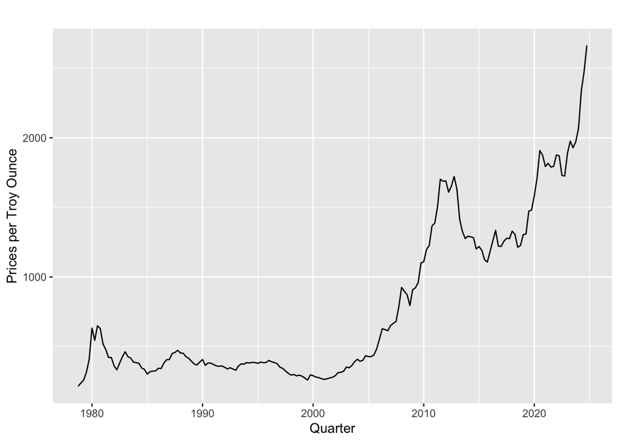

```r
library(ggplot2)

gold_data <- read_excel("~/Downloads/Gold_by_Quarter.xlsx")

gold.USD.ts <- ts(gold_data$USD, start = c(1978, 4), end = c(2024, 4), freq = 4)

autoplot(gold.USD.ts) + xlab("Quarter") + ylab("Prices per Troy Ounce")
```

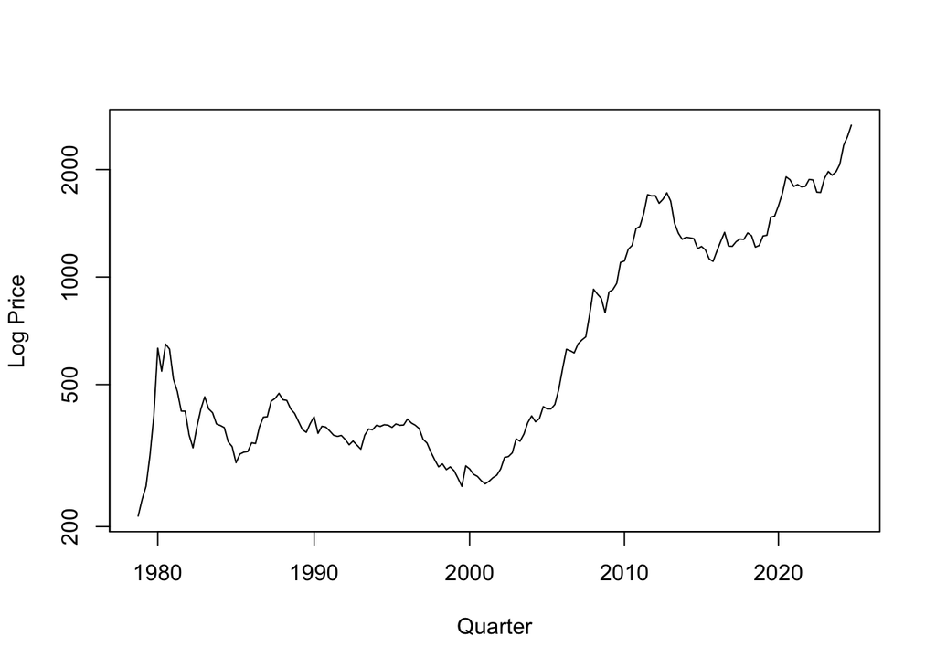

```r
plot(gold.USD.ts, xlab = "Quarter", ylab = "Log Price", log = 'xy')
```

```r
quarterly.avg <- tapply(gold.USD.ts, cycle(gold.USD.ts), mean)
print(quarterly.avg)
```

```
##        1        2        3        4
## 775.9620 783.6935 796.0276 795.5445
```

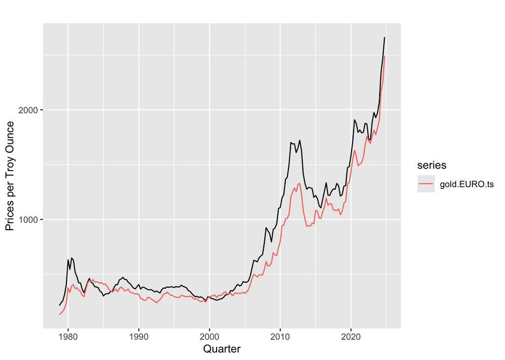

```r
gold.EURO.ts <- ts(gold_data$EUR, start = c(1978, 4), end = c(2024, 4), freq = 4)

autoplot(gold.USD.ts) + xlab("Quarter") + ylab("Prices per Troy Ounce") + autolayer(gold.EURO.ts)
```

The log price of gold is not linear which does not indicate an exponential relationship.

```r
SP_500 <- read_excel("~/Downloads/S&P.xlsx")
SP_500 <- SP_500[SP_500$USE == 1,]
SP.ts <- ts(SP_500$`Avg Price`, start = c(1979, 4), end = c(2024, 4), freq = 4)
tail(SP.ts)
```

```
##          Qtr1     Qtr2     Qtr3     Qtr4
## 2023                   4458.176 4471.505
## 2024 4999.383 5254.286 5545.827 5911.048
```

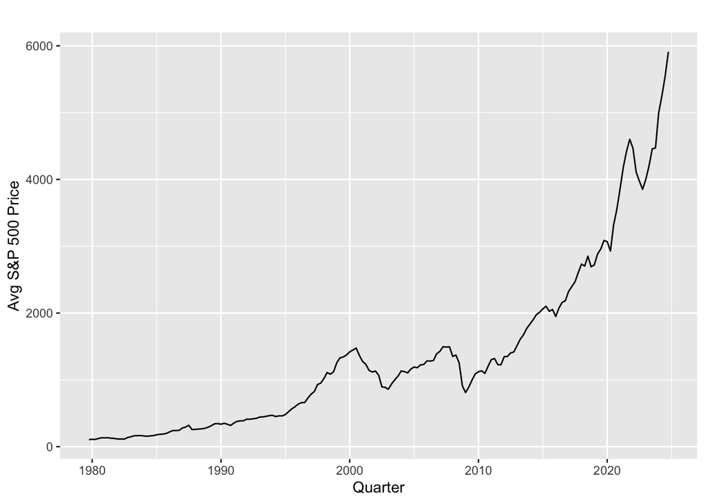

```r
autoplot(SP.ts) + xlab("Quarter") + ylab("Avg S&P 500 Price")
```

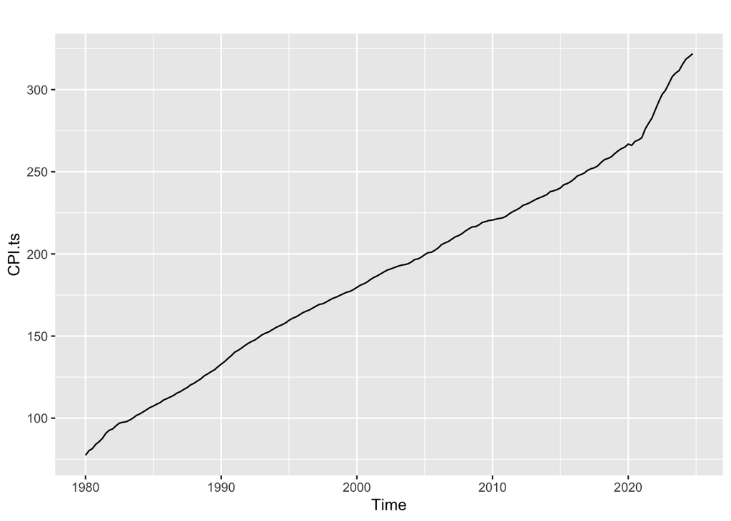

```r
CPI <- read_excel("~/Downloads/Quarterly_CPI.xlsx")
CPI$USE <- ifelse(CPI$QUARTER == 'S',0,CPI$USE)
CPI <- CPI[CPI$USE == 1,]
CPI.ts <- ts(CPI$AVG, start = c(1980, 1), end = c(2024, 4), freq = 4)
autoplot(CPI.ts)
```

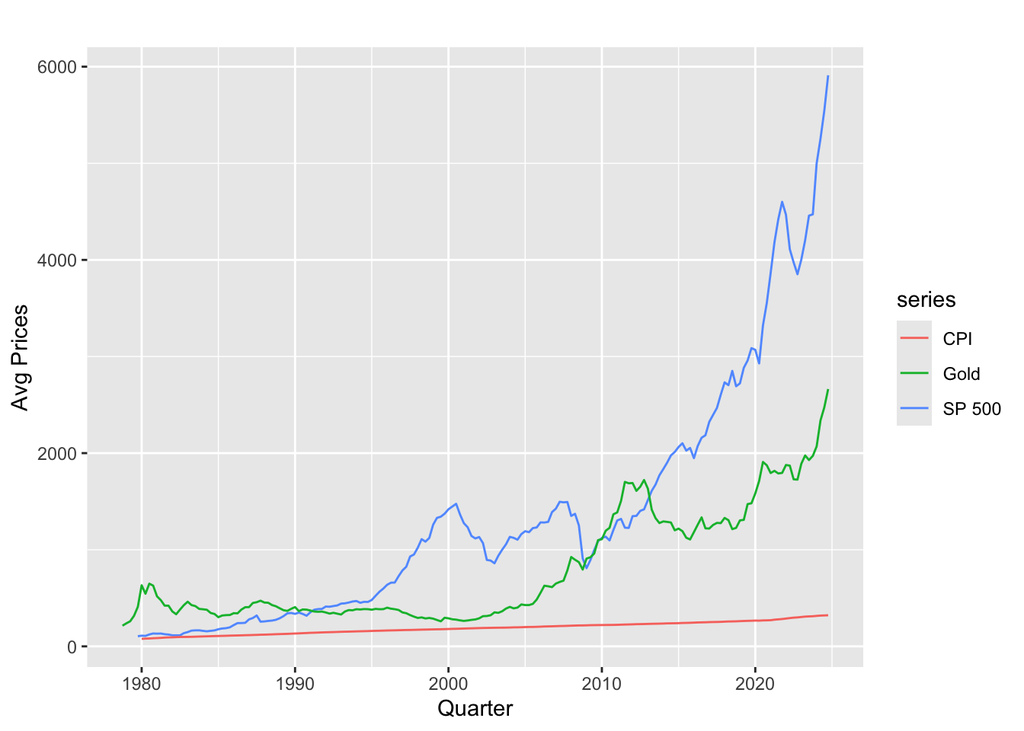

```r
autoplot(SP.ts, series = "SP 500") + xlab("Quarter") + ylab("Avg Prices") + autolayer(gold.USD.ts, series = "Gold") + autolayer(CPI.ts, series = "CPI")
```

```r
correlation_SP <- cor(gold_data$USD[5:185], SP_500$`Avg Price`)
correlation_SP
```

```
## [1] 0.8583329
```

```r
correlation_CPI <- cor(gold_data$USD[6:185], CPI$AVG)
correlation_CPI
```

```
## [1] 0.8348685
```

The Quarterly price of gold is highly correlated with both the S&P 500 and Consumer Price Index showing that gold prices move in as imilair pattern as inflation and the overall market.

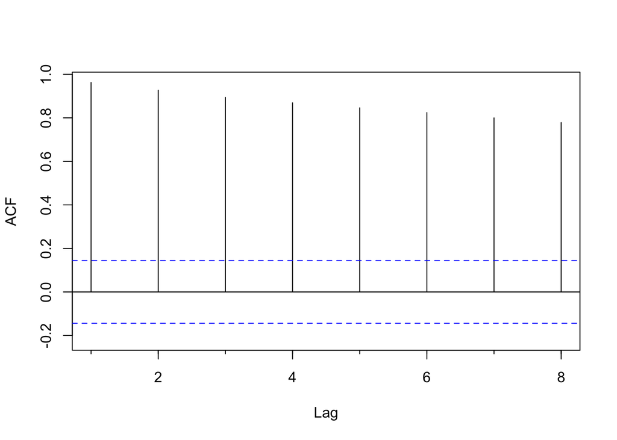

```r
Acf(gold.USD.ts, lag.max = 8, main = "")
```

```r
gold.ar1 <- Arima(diff(gold.USD.ts), order = c(1,0,0))
summary(gold.ar1)
```

```
## Series: diff(gold.USD.ts)
## ARIMA(1,0,0) with non-zero mean
##
## Coefficients:
##          ar1     mean
##       0.3168  13.7795
## s.e.  0.0714   6.3697
##
## sigma^2 = 3539:  log likelihood = -1011.92
## AIC=2029.84   AICc=2029.97   BIC=2039.49
##
## Training set error measures:
##                       ME    RMSE     MAE       MPE     MAPE      MASE
## Training set -0.02079187 59.1656 40.2145 -25.06829 302.6279 0.7639266
##                     ACF1
## Training set -0.01016845
```

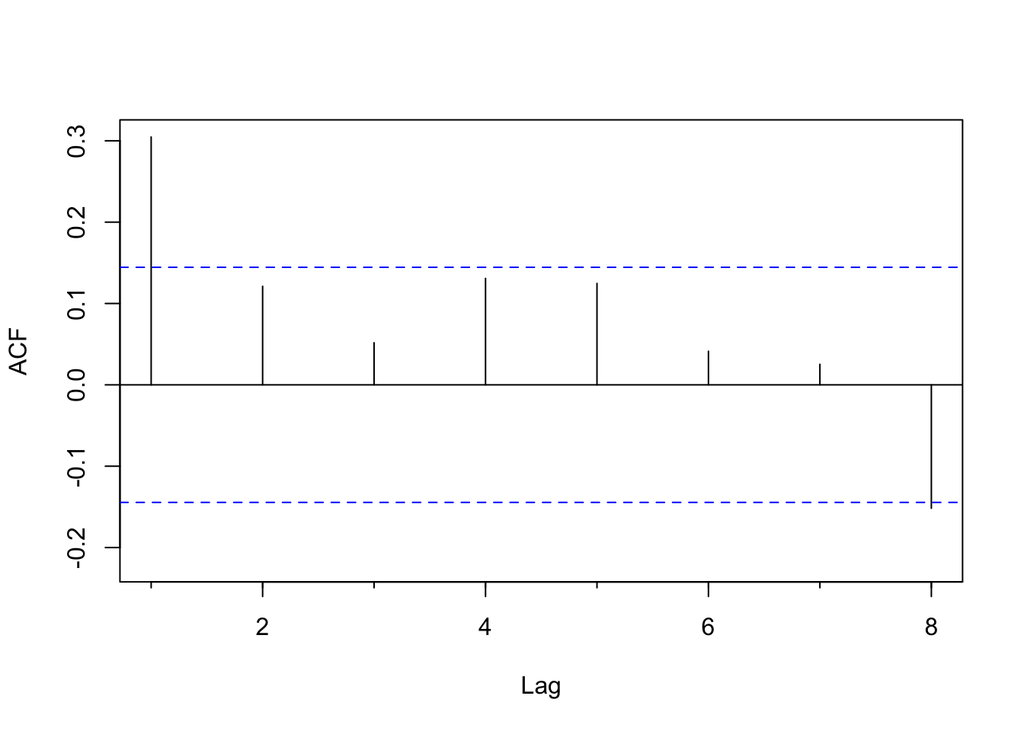

```r
Acf(diff(gold.USD.ts), lag.max = 8, main = "")
```

The Ar1 coefficient is more than 5 standard errors from 1 indicating it is NOT a random walk.

```r
stepsAhead <- 8

nTrain <- length(gold.USD.ts) - stepsAhead

train.ts <- window(gold.USD.ts, start = c(1978,4), end = c(1979,nTrain-1))

head(train.ts)
```

```
##        Qtr1   Qtr2   Qtr3   Qtr4
## 1978                      214.05
## 1979 238.10 259.25 315.70 408.41
## 1980 632.09
```

```r
tail(train.ts)
```

```
##         Qtr1    Qtr2    Qtr3    Qtr4
## 2021                 1789.52 1795.25
## 2022 1877.16 1870.58 1728.91 1725.85
```

```r
valid.ts <- window(gold.USD.ts, start = c(1979,nTrain), end = c(1979,nTrain+stepsAhead))
valid.ts
```

```
##         Qtr1    Qtr2    Qtr3    Qtr4
## 2023 1889.92 1975.93 1928.48 1971.49
## 2024 2069.80 2338.18 2474.29 2663.38
```

Split the data into training and validation using the last two year as the validation data (2023 and 2024). We will sue these model to forecast the price of godl for the next two years(2025 and 2026)

```r
gold.linear<- tslm(train.ts ~ trend)
summary(gold.linear)
```

```
##
## Call:
## tslm(formula = train.ts ~ trend)
##
## Residuals:
##     Min      1Q  Median      3Q     Max
## -479.02 -204.98    2.53  192.66  632.34
##
## Coefficients:
##             Estimate Std. Error t value Pr(>|t|)
## (Intercept)  13.3902    44.8579   0.299    0.766
## trend         8.0029     0.4371  18.309   <2e-16 ***
## ---
## Signif. codes:  0 '***' 0.001 '**' 0.01 '*' 0.05 '.' 0.1 ' ' 1
##
## Residual standard error: 297.1 on 175 degrees of freedom
## Multiple R-squared:  0.657,  Adjusted R-squared:  0.655
## F-statistic: 335.2 on 1 and 175 DF,  p-value: < 2.2e-16
```

```r
gold.linear.forecast <- forecast(gold.linear, h=8, level = 0)
accuracy(gold.linear.forecast,valid.ts)
```

```
##                         ME     RMSE      MAE       MPE     MAPE     MASE
## Training set -4.046481e-14 295.4510 241.9938 -16.93453 50.67244 2.552136
## Test set      6.980081e+02 742.8333 698.0081  31.35270 31.35270 7.361393
##                   ACF1 Theil's U
## Training set 0.9778868        NA
## Test set     0.5951998  5.251589
```

```r
gold.exp <- tslm(train.ts ~ trend , lambda = 0)
summary(gold.exp)
```

```
##
## Call:
## tslm(formula = train.ts ~ trend, lambda = 0)
##
## Residuals:
##      Min       1Q   Median       3Q      Max
## -0.80372 -0.19973  0.06504  0.26378  0.92255
##
## Coefficients:
##              Estimate Std. Error t value Pr(>|t|)
## (Intercept) 5.4722995  0.0587287   93.18   <2e-16 ***
## trend       0.0100612  0.0005723   17.58   <2e-16 ***
## ---
## Signif. codes:  0 '***' 0.001 '**' 0.01 '*' 0.05 '.' 0.1 ' ' 1
##
## Residual standard error: 0.389 on 175 degrees of freedom
## Multiple R-squared:  0.6385, Adjusted R-squared:  0.6364
## F-statistic: 309.1 on 1 and 175 DF,  p-value: < 2.2e-16
```

```r
gold.exp.forecast <- forecast(gold.exp, h= 8, level = 0)
accuracy(gold.exp.forecast,valid.ts)
```

```
##                     ME     RMSE      MAE       MPE     MAPE     MASE      ACF1
## Training set  62.79703 268.1032 201.9111 -7.992201 33.49145 2.129412 0.9739577
## Test set     685.59371 726.2640 685.5937 30.851865 30.85187 7.230467 0.5919010
##              Theil's U
## Training set        NA
## Test set      5.131483
```

```r
#Quadratic produced the lowest MAPE
gold.quad <- tslm(train.ts ~ trend + I(trend^2))
summary(gold.quad)
```

```
##
## Call:
## tslm(formula = train.ts ~ trend + I(trend^2))
##
## Residuals:
##     Min      1Q  Median      3Q     Max
## -322.33 -156.42    6.42   71.42  705.37
##
## Coefficients:
##               Estimate Std. Error t value Pr(>|t|)
## (Intercept) 522.563184  44.346368   11.78  < 2e-16 ***
## trend        -9.064300   1.150313   -7.88 3.42e-13 ***
## I(trend^2)    0.095883   0.006259   15.32  < 2e-16 ***
## ---
## Signif. codes:  0 '***' 0.001 '**' 0.01 '*' 0.05 '.' 0.1 ' ' 1
##
## Residual standard error: 194.4 on 174 degrees of freedom
## Multiple R-squared:  0.854,  Adjusted R-squared:  0.8523
## F-statistic: 508.7 on 2 and 174 DF,  p-value: < 2.2e-16
```

```r
gold.quad.forecast <- forecast(gold.quad, h=8, level = 0)
accuracy(gold.quad.forecast,valid.ts)
```

```
##                    ME     RMSE      MAE       MPE     MAPE     MASE      ACF1
## Training set   0.0000 192.7905 138.1686 -8.135798 24.22972 1.457166 0.9477868
## Test set     127.4218 251.8177 171.9149  4.805586  7.11325 1.813064 0.5852758
##              Theil's U
## Training set        NA
## Test set      1.692068
```

```r
gold.szn <- tslm(train.ts ~ season)
summary(gold.szn)
```

```
##
## Call:
## tslm(formula = train.ts ~ season)
##
## Residuals:
##    Min     1Q Median     3Q    Max
## -513.9 -369.1 -306.9  481.0 1176.4
##
## Coefficients:
##              Estimate Std. Error t value Pr(>|t|)
## (Intercept) 721.23932   76.92376   9.376   <2e-16 ***
## season2       0.02864  108.78662   0.000    1.000
## season3      10.90841  108.78662   0.100    0.920
## season4       6.66557  108.18057   0.062    0.951
## ---
## Signif. codes:  0 '***' 0.001 '**' 0.01 '*' 0.05 '.' 0.1 ' ' 1
##
## Residual standard error: 510.3 on 173 degrees of freedom
## Multiple R-squared:  8.408e-05,  Adjusted R-squared:  -0.01726
## F-statistic: 0.004849 on 3 and 173 DF,  p-value: 0.9995
```

```r
gold.szn.forecast <- forecast(gold.szn, h=8, level = 0)
accuracy(gold.szn.forecast,valid.ts)
```

```
##                        ME     RMSE       MAE       MPE     MAPE      MASE
## Training set 5.652227e-14  504.456  443.5314 -48.68416 79.16567  4.677608
## Test set     1.438294e+03 1463.380 1438.2938  65.97934 65.97934 15.168657
##                   ACF1 Theil's U
## Training set 0.9795614        NA
## Test set     0.5973123  10.46432
```

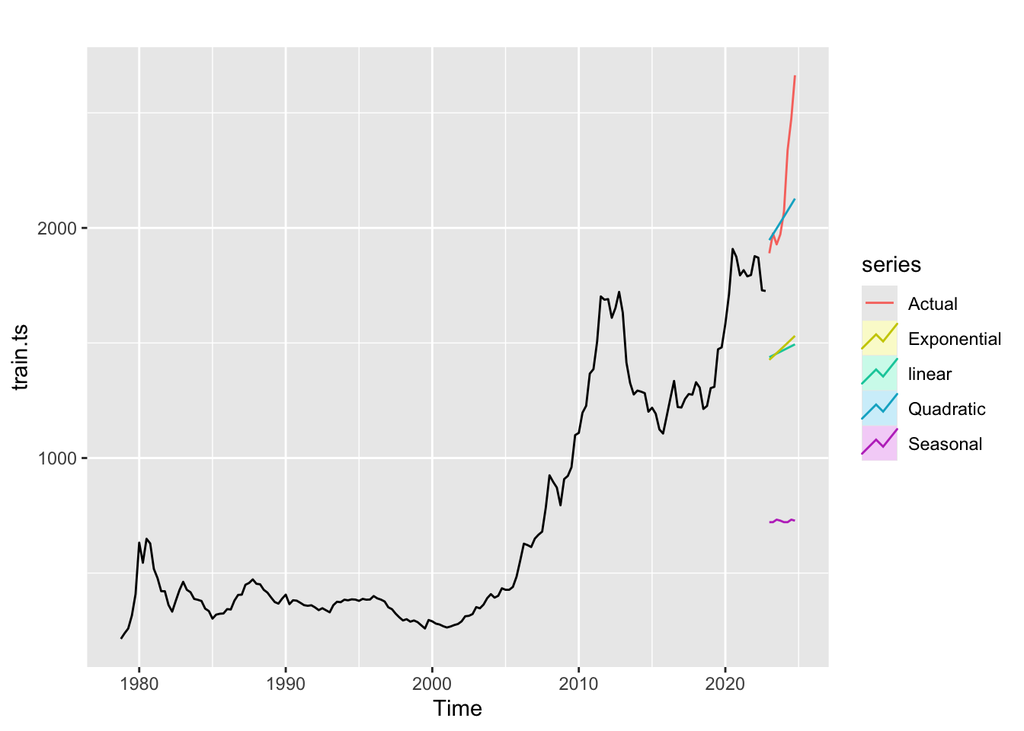

```r
autoplot(train.ts) + autolayer(valid.ts, series = "Actual") + autolayer(gold.linear.forecast, series = "linear") + autolayer(gold.exp.forecast, series = "Exponential") + autolayer(gold.quad.forecast, series = "Quadratic") + autolayer(gold.szn.forecast, series = "Seasonal")
```

Ran all the basic models and found that the quadratic model was suprisingly accurate with a MAPE of 7.11 Choose not to run snaive. Also of note the seasonality of this data is very poor and adding it to models tend to make them more inaccurate

```r
gold.linear.szn <- tslm(train.ts ~ trend + season)
summary(gold.linear.szn)
```

```
##
## Call:
## tslm(formula = train.ts ~ trend + season)
##
## Residuals:
##     Min      1Q  Median      3Q     Max
## -481.28 -203.47    3.28  190.85  633.83
##
## Coefficients:
##             Estimate Std. Error t value Pr(>|t|)
## (Intercept)  16.9370    59.5556   0.284    0.776
## trend         8.0034     0.4409  18.152   <2e-16 ***
## season2      -7.9748    63.8973  -0.125    0.901
## season3      -5.0985    63.9019  -0.080    0.937
## season4      -1.3379    63.5413  -0.021    0.983
## ---
## Signif. codes:  0 '***' 0.001 '**' 0.01 '*' 0.05 '.' 0.1 ' ' 1
##
## Residual standard error: 299.7 on 172 degrees of freedom
## Multiple R-squared:  0.657,  Adjusted R-squared:  0.6491
## F-statistic: 82.38 on 4 and 172 DF,  p-value: < 2.2e-16
```

```r
gold.linear.szn.forecast <- forecast(gold.linear.szn, h = 8, level = 0)
accuracy(gold.linear.szn.forecast, valid.ts)
```

```
##                         ME     RMSE      MAE       MPE     MAPE     MASE
## Training set -7.707582e-15 295.4344 242.0324 -16.93232 50.66520 2.552543
## Test set      6.979760e+02 742.9228 697.9760  31.34891 31.34891 7.361054
##                   ACF1 Theil's U
## Training set 0.9780596        NA
## Test set     0.5934757  5.255502
```

```r
gold.poly.szn <- tslm(train.ts ~ trend + I(trend^2)+ season)
summary(gold.poly.szn)
```

```
##
## Call:
## tslm(formula = train.ts ~ trend + I(trend^2) + season)
##
## Residuals:
##     Min      1Q  Median      3Q     Max
## -316.26 -152.60    6.21   65.48  704.04
##
## Coefficients:
##               Estimate Std. Error t value Pr(>|t|)
## (Intercept) 529.135484  51.528135  10.269  < 2e-16 ***
## trend        -9.069847   1.160302  -7.817 5.29e-13 ***
## I(trend^2)    0.095917   0.006314  15.192  < 2e-16 ***
## season2      -7.878882  41.807143  -0.188    0.851
## season3      -5.098462  41.810128  -0.122    0.903
## season4     -12.624136  41.580880  -0.304    0.762
## ---
## Signif. codes:  0 '***' 0.001 '**' 0.01 '*' 0.05 '.' 0.1 ' ' 1
##
## Residual standard error: 196.1 on 171 degrees of freedom
## Multiple R-squared:  0.854,  Adjusted R-squared:  0.8498
## F-statistic: 200.1 on 5 and 171 DF,  p-value: < 2.2e-16
```

```r
gold.poly.szn.forecast <- forecast(gold.poly.szn, h = 8, level = 0)
accuracy(gold.poly.szn.forecast, valid.ts)
```

```
##                        ME     RMSE      MAE       MPE      MAPE     MASE
## Training set 2.569194e-15 192.7360 138.0429 -8.130762 24.222559 1.455840
## Test set     1.271401e+02 253.3116 172.2048  4.782380  7.123129 1.816121
##                   ACF1 Theil's U
## Training set 0.9484606        NA
## Test set     0.5750226  1.699641
```

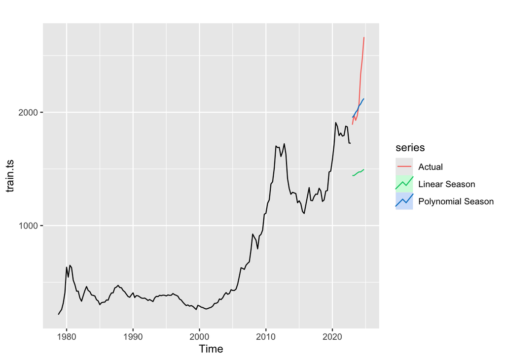

```r
autoplot(train.ts) + autolayer(valid.ts, series = "Actual") + autolayer(gold.linear.szn.forecast, series = "Linear Season") + autolayer(gold.poly.szn.forecast, series = "Polynomial Season")
```

The quadratic with seasonality performs well but not as well as the quadratic without seasonality which is why seasonality will not be in included.

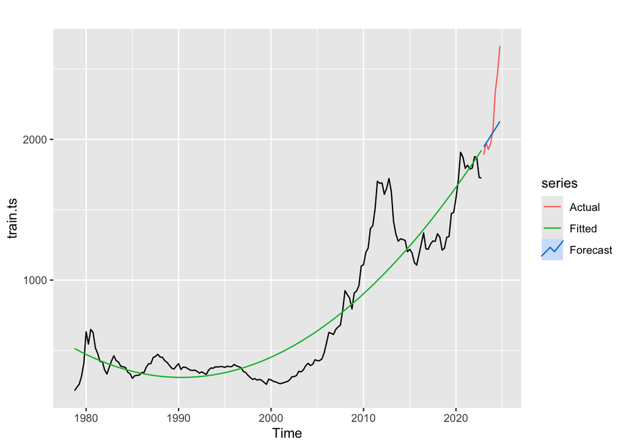

```r
autoplot(train.ts) + autolayer(valid.ts, series = "Actual") + autolayer(gold.quad.forecast$fitted, series = "Fitted") + autolayer(gold.quad.forecast, series = "Forecast")
```

Fitted values to show the full quadratic model.

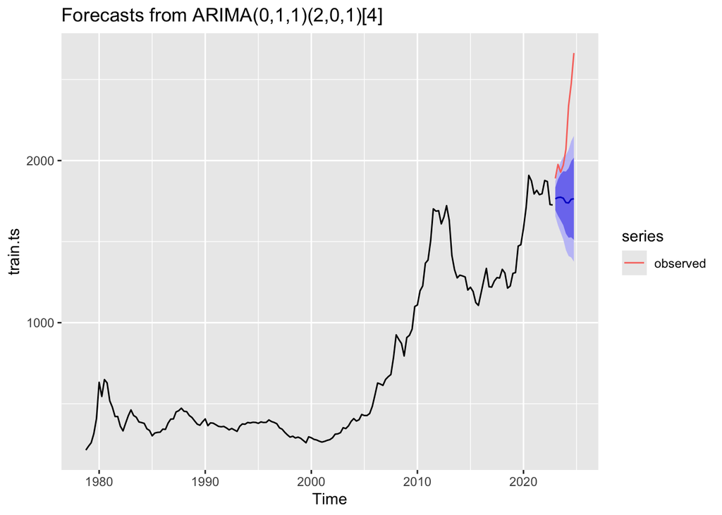

```r
gold.arima <- auto.arima(train.ts)

gold.arima.forecast <- forecast(gold.arima, h = 8)

autoplot(gold.arima.forecast) + autolayer(valid.ts, series = "observed")
```

```r
accuracy(gold.arima.forecast, valid.ts)
```

```
##                     ME      RMSE       MAE        MPE      MAPE      MASE
## Training set   7.31769  53.94078  34.78624  0.7892834  4.954281 0.3668657
## Test set     403.58541 488.27065 403.58541 17.4296670 17.429667 4.2563270
##                     ACF1 Theil's U
## Training set 0.006630104        NA
## Test set     0.610985477  3.397956
```

AutoArima model performed very poorly with a MAPE of 17.43.

```r
gold.hwin <- ets(train.ts, model ="ZZZ")
summary(gold.hwin)
```

```
## ETS(M,A,N)
##
## Call:
## ets(y = train.ts, model = "ZZZ")
##
##   Smoothing parameters:
##     alpha = 0.9999
##     beta  = 0.1502
##
##   Initial states:
##     l = 176.2985
##     b = 44.8393
##
##   sigma:  0.0723
##
##      AIC     AICc      BIC
## 2246.392 2246.743 2262.273
##
## Training set error measures:
##                     ME     RMSE      MAE        MPE     MAPE      MASE
## Training set -1.688451 56.60184 36.81405 -0.2370431 5.068334 0.3882515
##                   ACF1
## Training set 0.1317542
```

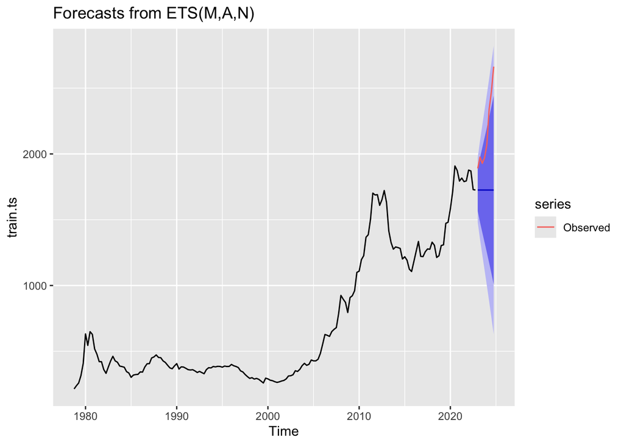

```r
gold.hwin.forecast <- forecast(gold.hwin, h = 8)

autoplot(gold.hwin.forecast) + autolayer(valid.ts, series = "Observed")
```

```r
accuracy(gold.hwin.forecast,valid.ts)
```

```
##                      ME      RMSE       MAE        MPE      MAPE      MASE
## Training set  -1.688451  56.60184  36.81405 -0.2370431  5.068334 0.3882515
## Test set     438.278688 515.38808 438.27869 19.0786047 19.078605 4.6222121
##                   ACF1 Theil's U
## Training set 0.1317542        NA
## Test set     0.5985803  3.591661
```

Holt Winters performed even worse with a MAPE of 19.07 and will not be used.

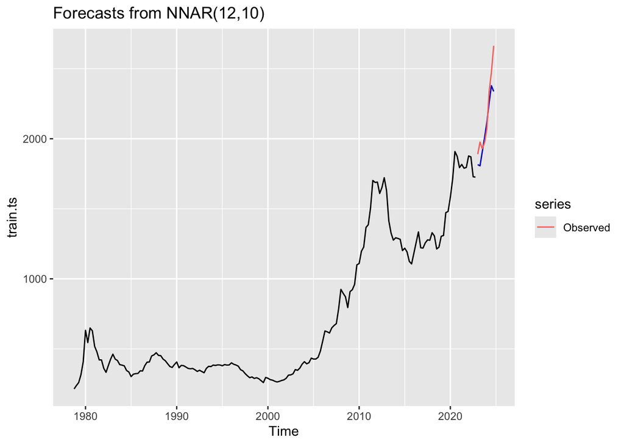

```r
set.seed(2025)
gold.nn<- nnetar(train.ts, repeats =30, p = 12 , P = 0, size = 10)

gold.nn.pred <- forecast(gold.nn, h = 8)

autoplot(gold.nn.pred) + autolayer(valid.ts, series = "Observed") # + autolayer(gold.nn$fitted)
```

```r
accuracy(gold.nn.pred, valid.ts)
```

```
##                       ME      RMSE       MAE        MPE     MAPE     MASE
## Training set  0.01296547  14.25085  10.24863 -0.1083252 2.191855 0.108085
## Test set     85.61256449 141.35073 106.15811  3.6373268 4.651593 1.119574
##                     ACF1 Theil's U
## Training set -0.05106411        NA
## Test set      0.20213718 0.9663392
```

The neural netwoirk performs very well using the last 12 quarters (p), no seasonality(P), 10 hidden layers (size), and 30 iterations. Lowest MAPE so far.

```r
combined.simple <- (gold.quad.forecast$mean + gold.nn.pred$mean)/2

accuracy(combined.simple,valid.ts)
```

```
##                ME     RMSE      MAE      MPE     MAPE      ACF1 Theil's U
## Test set 106.5172 187.2432 126.7032 4.221456 5.244572 0.4437175  1.257764
```

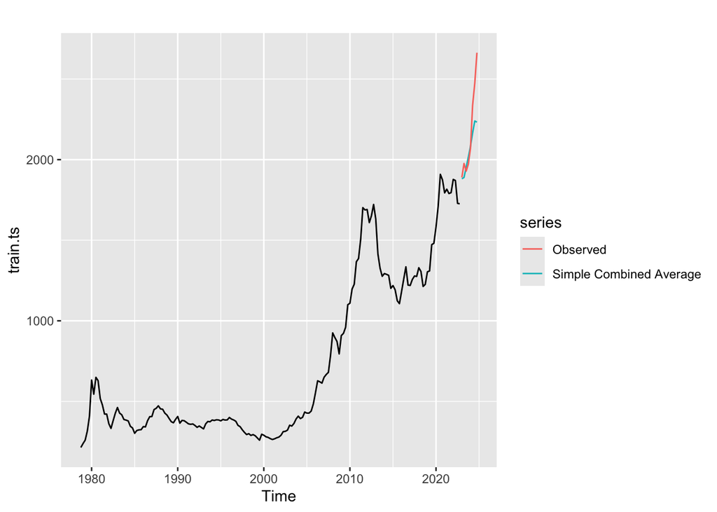

```r
autoplot(train.ts) +
  autolayer(combined.simple, series = "Simple Combined Average") +
  autolayer(valid.ts, series = "Observed")
```

The simple combined average between the neural network and quadratic performed well but slightly worse than the neural network.

```r
vectors.df <- data.frame(cbind(gold.quad.forecast$mean , gold.nn.pred$mean))
vectors.df$trimmed.average <- apply(vectors.df, 1, function(x) mean(x, trim = 0.5))
trimmed.average <- ts(vectors.df$trimmed.average, start = c(2023, 1), end = c(2024, 4), freq = 4)

accuracy(trimmed.average, valid.ts)
```

```
##                ME     RMSE      MAE      MPE     MAPE      ACF1 Theil's U
## Test set 106.5172 187.2432 126.7032 4.221456 5.244572 0.4437175  1.257764
```

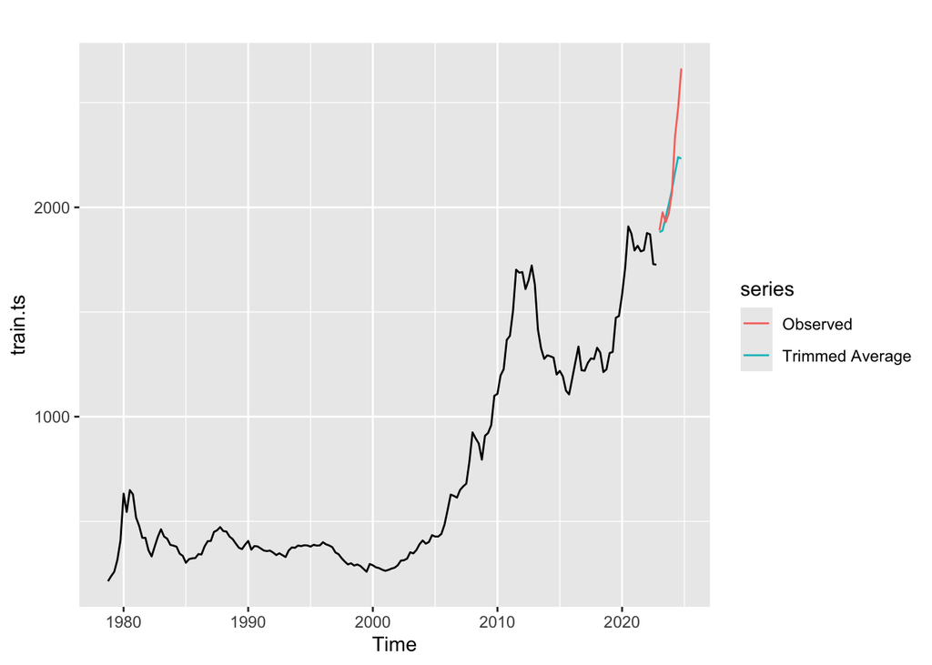

```r
autoplot(train.ts) +
  autolayer(trimmed.average, series = "Trimmed Average") +
  autolayer(valid.ts, series = "Observed")
```

A trimmed average performs similairly to the simple average

```r
vectors.df$valid <- valid.ts
lm.vectors <- data.frame(vectors.df[1:4,])
vector.lm <- lm(lm.vectors$valid ~ gold.quad.forecast.mean + gold.nn.pred.mean, data = lm.vectors)
summary(vector.lm)
```

```
##
## Call:
## lm(formula = lm.vectors$valid ~ gold.quad.forecast.mean + gold.nn.pred.mean,
##     data = lm.vectors)
##
## Residuals:
##        1        2        3        4
##   0.3867  14.2977 -29.6396  14.9551
##
## Coefficients:
##                           Estimate Std. Error t value Pr(>|t|)
## (Intercept)             -1955.0837  2438.0192  -0.802    0.570
## gold.quad.forecast.mean     2.6154     1.7475   1.497    0.375
## gold.nn.pred.mean          -0.6873     0.6082  -1.130    0.461
##
## Residual standard error: 36.15 on 1 degrees of freedom
## Multiple R-squared:  0.7341, Adjusted R-squared:  0.2024
## F-statistic: 1.381 on 2 and 1 DF,  p-value: 0.5156
```

```r
fourcast <-  (-1955.0837 + vectors.df$gold.quad.forecast.mean*2.6154 + vectors.df$gold.quad.forecast.mean*-0.6873)
regression <- ts(fourcast, start = c(2023,1), end=c(2024,4), freq=4)

accuracy(fourcast, valid.ts)
```

```
##                ME     RMSE      MAE      MPE     MAPE      ACF1 Theil's U
## Test set 192.4188 256.9189 192.4188 8.135097 8.135097 0.5625358  1.743871
```

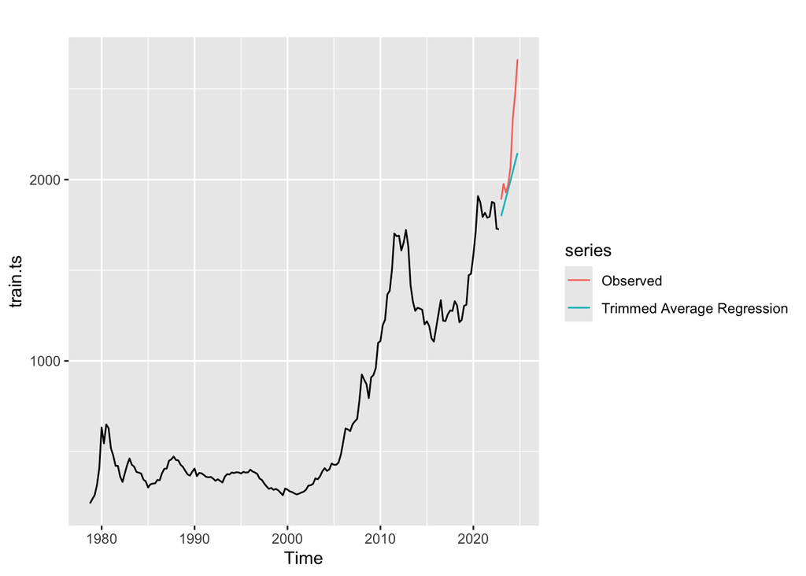

```r
autoplot(train.ts) +
  autolayer(regression, series = "Trimmed Average Regression") +
  autolayer(valid.ts, series = "Observed")
```

```r
lag1 <- diff(gold.USD.ts, lag = 1)
lag4 <- diff(gold.USD.ts, lag = 4)

diff.ts <- diff(diff(gold.USD.ts, lag = 4), lag = 1)
#print(diff.ts)
diff.nValid <- 8
diff.nTrain <- length(diff.ts) - diff.nValid
diff.train.ts <- window(diff.ts, start = c(1980, 1), end = c(1980, diff.nTrain+1))

diff.valid.ts <- window(diff.ts, start = c(1980, diff.nTrain + 2), end = c(1980, diff.nTrain + 1  + diff.nValid))
```

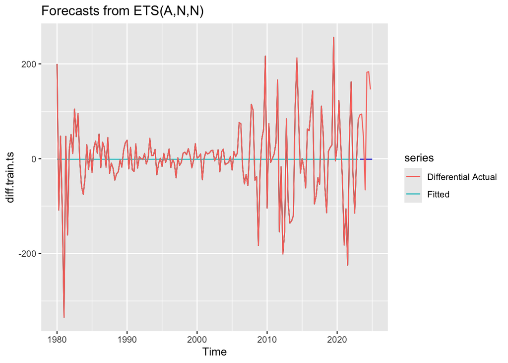

```r
smooth <- ets(diff.train.ts, model = "ZZZ")
smooth.forecast <- forecast(smooth, h = diff.nValid, level = 0)

autoplot(smooth.forecast) + autolayer(smooth.forecast$fitted, series = "Fitted") + autolayer(diff.ts, series = "Differential Actual")
```

```r
accuracy(smooth.forecast, diff.valid.ts)
```

```
##                         ME      RMSE       MAE      MPE     MAPE      MASE
## Training set -0.0009910326  76.07255  50.16844 117.2476 117.2476 0.6128256
## Test set     98.0604871099 127.39836 116.55137 100.6801 100.6801 1.4237170
##                   ACF1 Theil's U
## Training set 0.1603519        NA
## Test set     0.1336291 0.7892531
```

Ran a simple exponential smoothing model which performed very poorly.

```r
library(prophet)
prophet.df <- data.frame(ds = gold_data$Date[1:177], y = as.vector(gold_data$USD[1:177]))
p_model <- prophet(prophet.df)
```

```
## Disabling weekly seasonality. Run prophet with weekly.seasonality=TRUE to override this.
```

```
## Disabling daily seasonality. Run prophet with daily.seasonality=TRUE to override this.
```

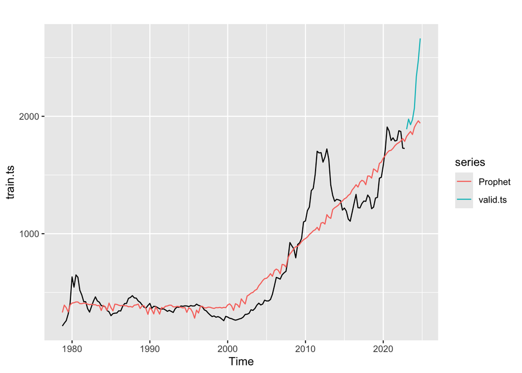

```r
valid.df <- make_future_dataframe(p_model, periods=8, freq='quarter')
prophet.predict <- predict(p_model, valid.df)
prophet.ts <- ts(prophet.predict$yhat, start = c(1978, 4), end = c(2024, 4), freq = 4)

autoplot(train.ts) + autolayer(valid.ts) + autolayer(prophet.ts, series = "Prophet")
```

```r
accuracy(prophet.predict$yhat[178:185], valid.ts)
```

```
##                ME     RMSE      MAE      MPE     MAPE      ACF1 Theil's U
## Test set 271.4646 355.5604 271.4646 11.49414 11.49414 0.5558517  2.432222
```

Tried a common model (not from class) the prohpet model that performs better than the arima and hol-winters but worse than the better models above.

Final Forecasts Decided to run the top three model by lowest MAPE with the neural network being the best MAPE above and will be used as the basis for our conclusions (aka our main model).

```r
set.seed(2025)

last_four <- ts(gold.USD.ts[169:185], start = c(2020,1), end = c(2024,4), freq = 4)

final.quad <- tslm(gold.USD.ts ~ trend + I(trend^2))
summary(final.quad)
```

```
##
## Call:
## tslm(formula = gold.USD.ts ~ trend + I(trend^2))
##
## Residuals:
##     Min      1Q  Median      3Q     Max
## -348.33 -152.99   -8.04   68.53  699.25
##
## Coefficients:
##               Estimate Std. Error t value Pr(>|t|)
## (Intercept) 539.053320  43.842568  12.295  < 2e-16 ***
## trend        -9.769119   1.088347  -8.976 3.45e-16 ***
## I(trend^2)    0.100628   0.005667  17.755  < 2e-16 ***
## ---
## Signif. codes:  0 '***' 0.001 '**' 0.01 '*' 0.05 '.' 0.1 ' ' 1
##
## Residual standard error: 196.6 on 182 degrees of freedom
## Multiple R-squared:  0.8855, Adjusted R-squared:  0.8843
## F-statistic: 703.9 on 2 and 182 DF,  p-value: < 2.2e-16
```

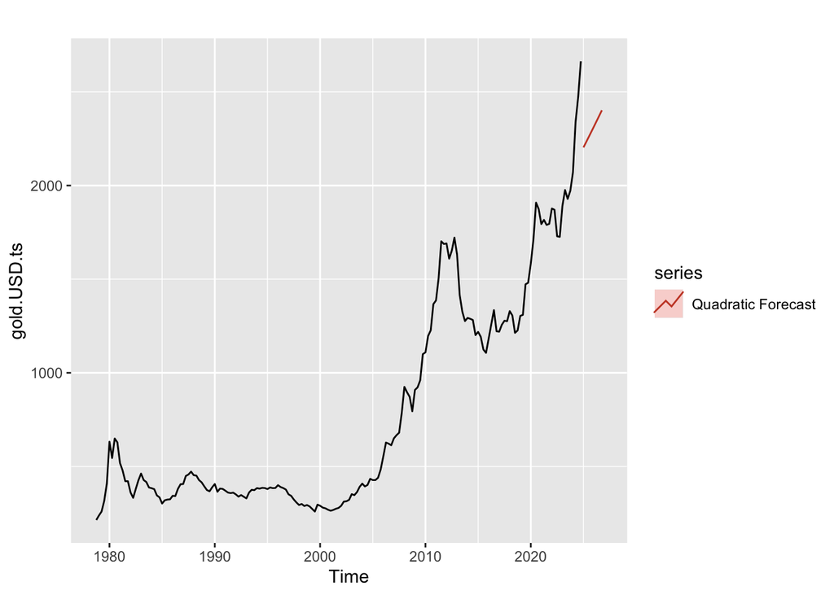

```r
final.quad.forecast <- forecast(final.quad, h=8, level = 0)
autoplot(gold.USD.ts) + autolayer(final.quad.forecast, series = "Quadratic Forecast")
```

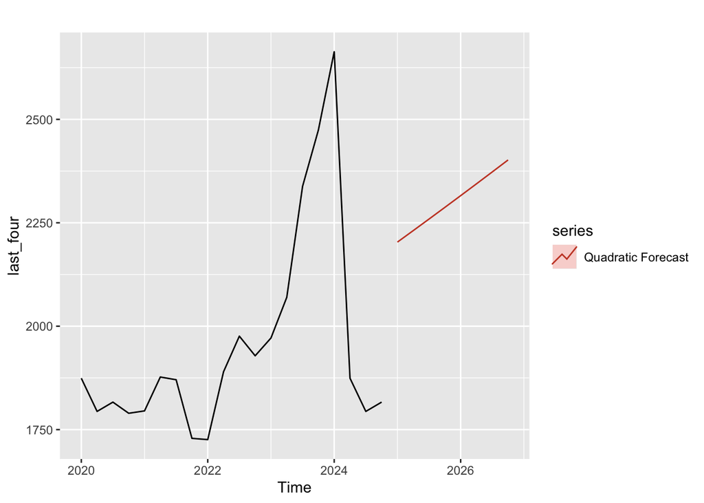

```r
autoplot(last_four) + autolayer(final.quad.forecast, series = "Quadratic Forecast")
```

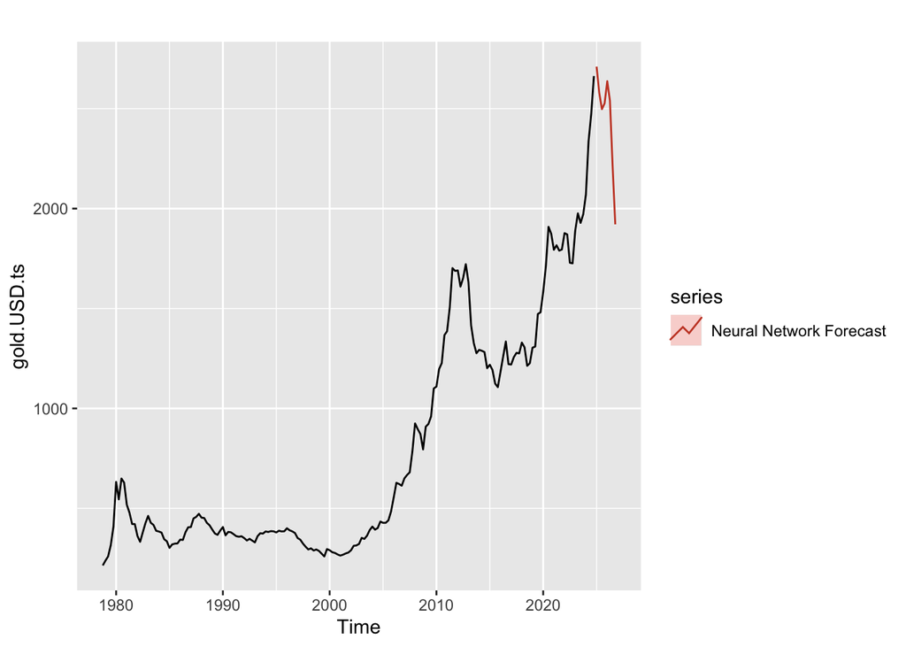

```r
final.nn <- nnetar(gold.USD.ts, repeats =50, p = 12 , P = 3, size = 10)
final.nn.pred <- forecast(final.nn, h = 8)
autoplot(gold.USD.ts) +  autolayer(final.nn.pred, series = "Neural Network Forecast")
```

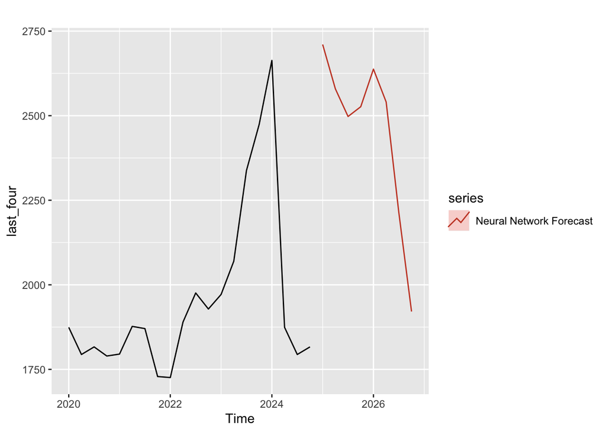

```r
autoplot(last_four) + autolayer(final.nn.pred, series = "Neural Network Forecast")
```

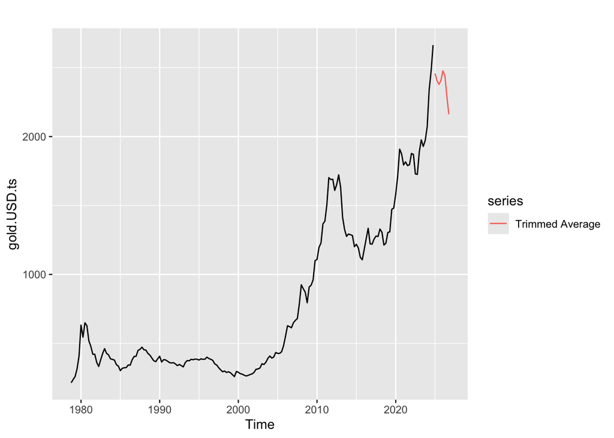

```r
final.vectors.df <- data.frame(cbind(final.quad.forecast$mean , final.nn.pred$mean))
final.vectors.df$trimmed.average <- apply(final.vectors.df, 1, function(x) mean(x, trim = 0.5))
final.trimmed.average <- ts(final.vectors.df$trimmed.average, start = c(2025, 1), end = c(2026, 4), freq = 4)
autoplot(gold.USD.ts) +  autolayer(final.trimmed.average, series = "Trimmed Average")
```

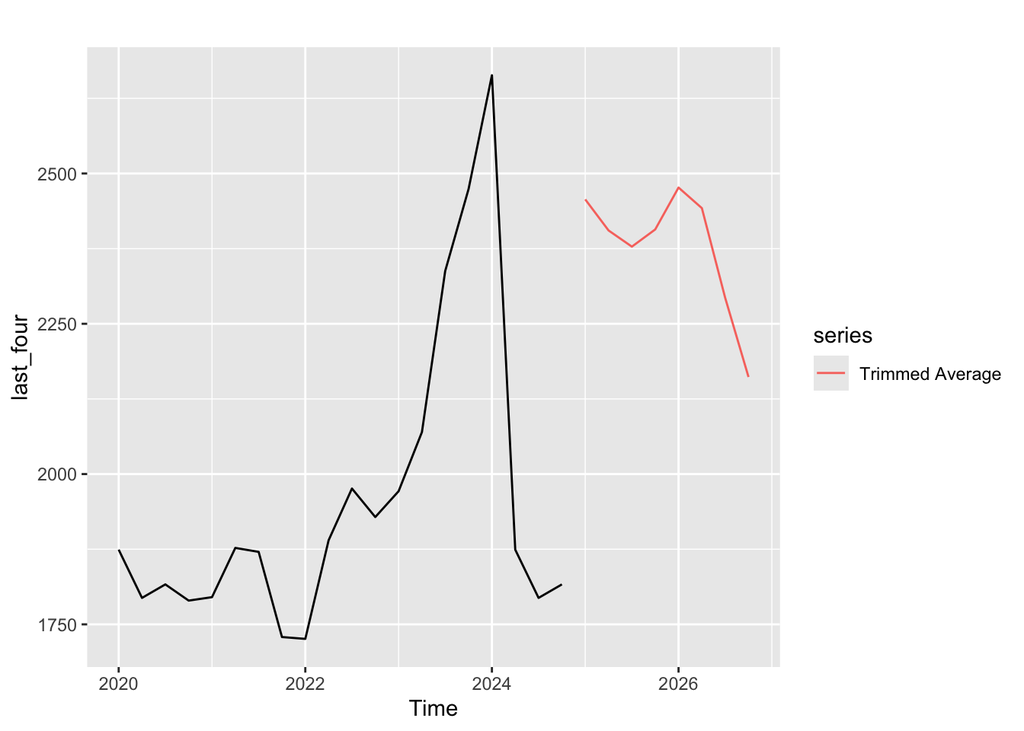

```r
autoplot(last_four) + autolayer(final.trimmed.average, series = "Trimmed Average")
```

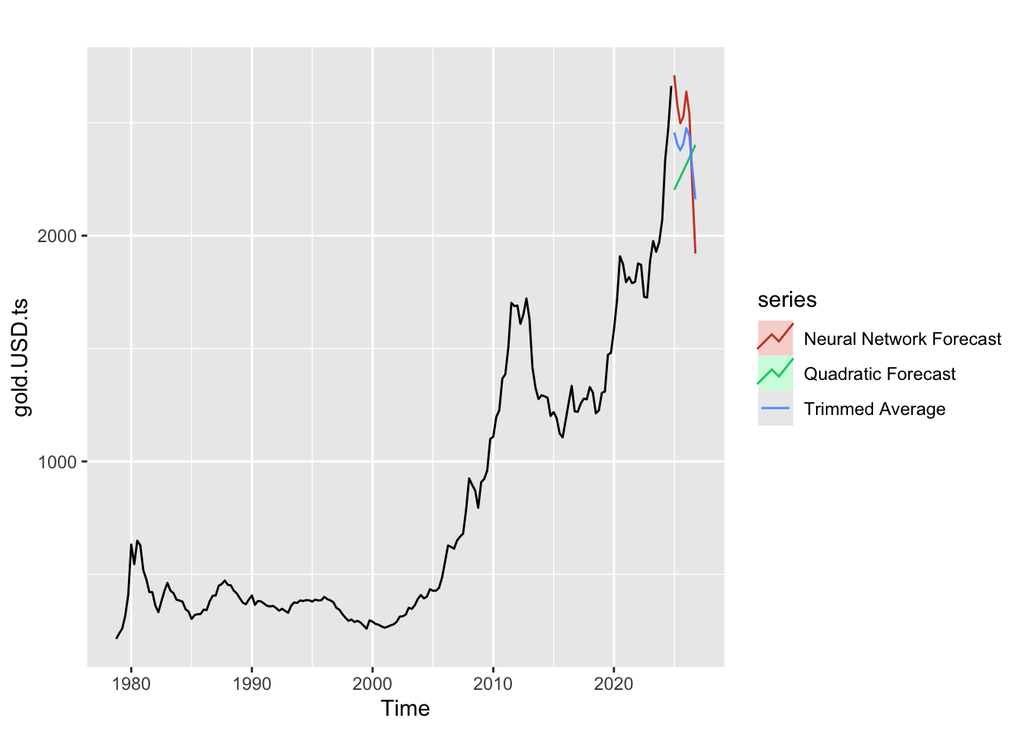

```r
autoplot(gold.USD.ts) + autolayer(final.quad.forecast, series = "Quadratic Forecast") + autolayer(final.nn.pred, series = "Neural Network Forecast") + autolayer(final.trimmed.average, series = "Trimmed Average")
```

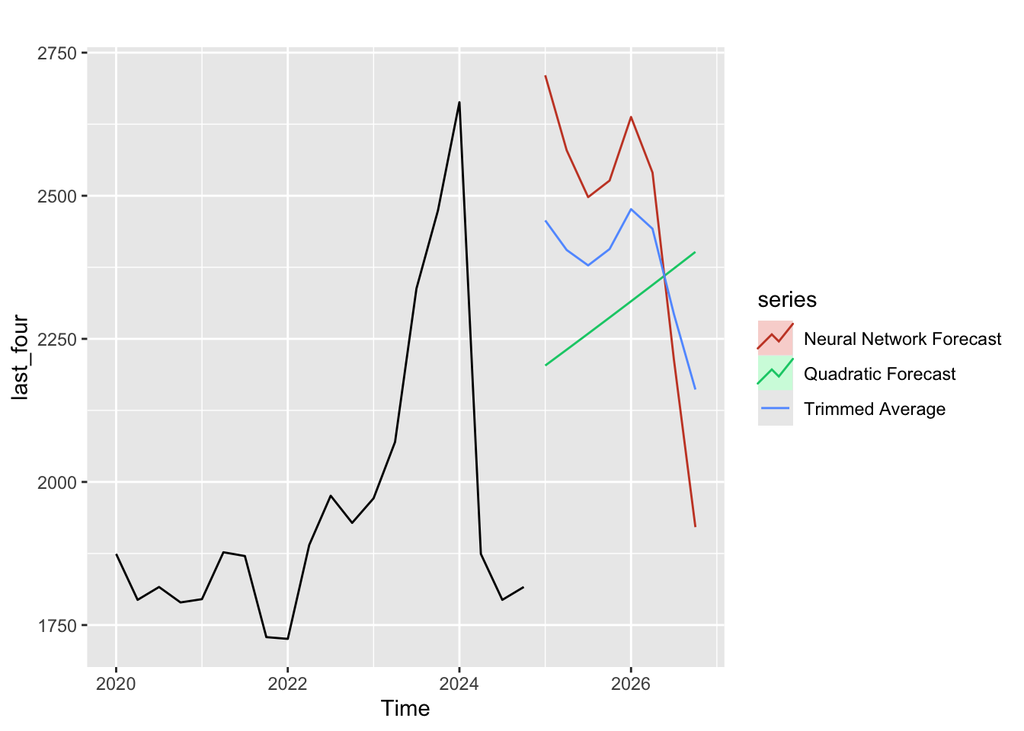

```r
autoplot(last_four) + autolayer(final.quad.forecast, series = "Quadratic Forecast") + autolayer(final.nn.pred, series = "Neural Network Forecast") + autolayer(final.trimmed.average, series = "Trimmed Average")
```

Analysis: The trimmed average is essential just an average of quadratic and neural network. Neural network predicts gold having a decline and a quick rebound to start 2026 then a fall off. The quadratic as it is a basic model shows a slight linear rise over the next two years (least accurate by mape from testing then these two). The trimmed average has a similair predicition to nn but is less drastic in its increases and decreases. Important to note that becuase gold was peaking for the last two years which became the validation data predicitons were hard. I tried only the last year as validation data but that made the MAPEs even worse.

Below is the numerical predicitons for the next two years. NEURAL NETWORK is the model we’ll use as the final one:

```r
print(final.quad.forecast)
```

```
##         Point Forecast     Lo 0     Hi 0
## 2025 Q1       2203.326 2203.326 2203.326
## 2025 Q2       2231.091 2231.091 2231.091
## 2025 Q3       2259.058 2259.058 2259.058
## 2025 Q4       2287.225 2287.225 2287.225
## 2026 Q1       2315.594 2315.594 2315.594
## 2026 Q2       2344.164 2344.164 2344.164
## 2026 Q3       2372.936 2372.936 2372.936
## 2026 Q4       2401.908 2401.908 2401.908
```

******* OUR PREDICITON ********************

```r
print(final.nn.pred)
```

```
##          Qtr1     Qtr2     Qtr3     Qtr4
## 2025 2710.483 2579.378 2497.558 2526.523
## 2026 2637.600 2540.568 2213.057 1921.059
```

```r
print(final.trimmed.average)
```

```
##          Qtr1     Qtr2     Qtr3     Qtr4
## 2025 2456.905 2405.235 2378.308 2406.874
## 2026 2476.597 2442.366 2292.996 2161.484
```